# Music corpus of Jonne Hoek Spaans

[figure not shown]

[figure not shown]

[figure not shown]

[figure not shown]

[figure not shown]

# Homepage

Some background and reasons why I chose this Corpus People say that Bossanova was pretty much born from West coast Jazz and it’s basically just a Brazilian version of it. Im curious how this is to be seen when looking into the data. I have grabbed a playlist of around 50 songs of both genres and will see how close these songs are related to each other by comparing their multiple features with one another. To hopefully create on overview on where the Brazilians have sticked with the American way and where they have chosen to bring their own flavour into the genre. With the Uk drill part of the corpus I will focus more on an artist than a genre. I will look at what makes Central C different from other Drill rappers like ArrDee or Aitch. Songs of Central C can sometimes be very emotional and sad but still pack a lot of energy, like the song Let go or One up. And he’s got a lot more songs and epecially remixes that are very unique. Im curious what the spotify features will say about a track like let it go and im curious if there are anny other rappers in the UK scene that have a songs with comparible feature values. So I would want to analyze some of his iconic tracks and than compare him as an artist to other UK artist and see where there difference is the biggest. And lastly with the Scales im curious to what scales Americans and the Dutch listen most. Are we very similair in this? Or do we differ in what scale we prefer?

# United States v.s. The Netherlands

### Chart A

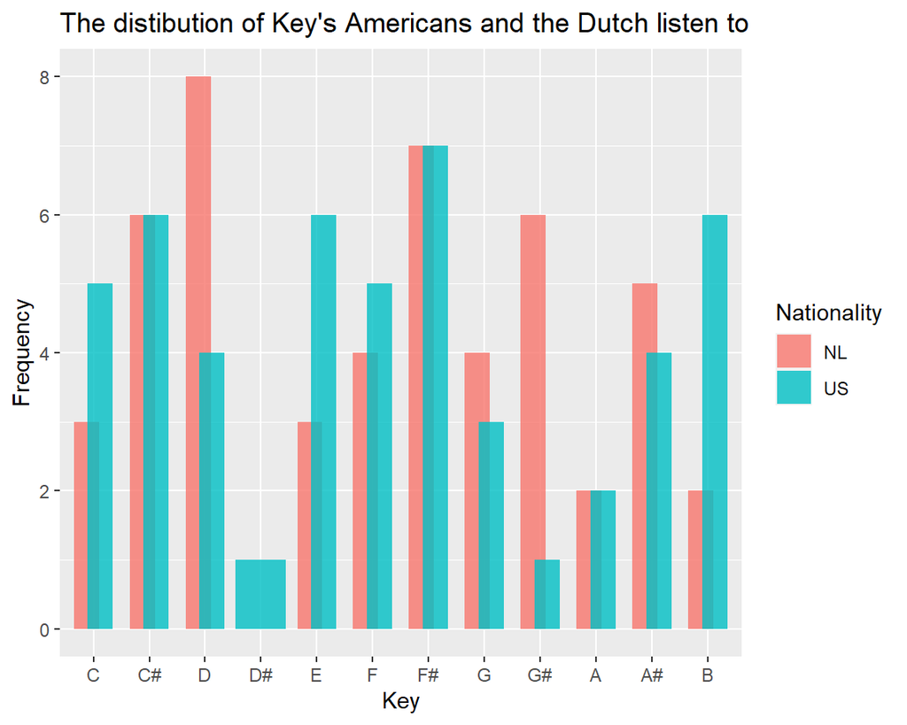

# Bossanova and West Coast Jazz

### Chart A

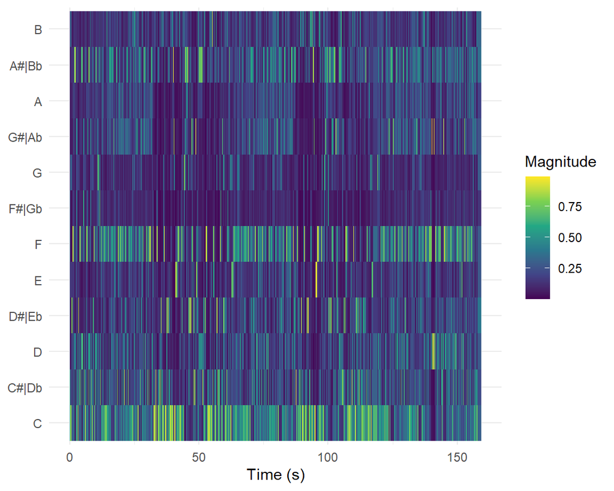

# Central C compared to other Drillers

### Musical profiles of the 3 different artist

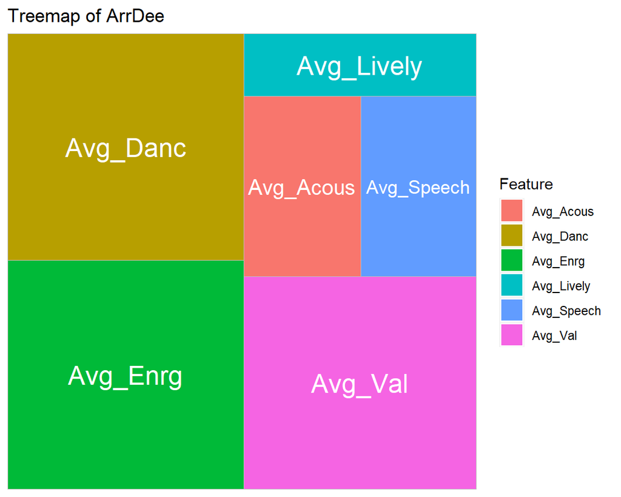

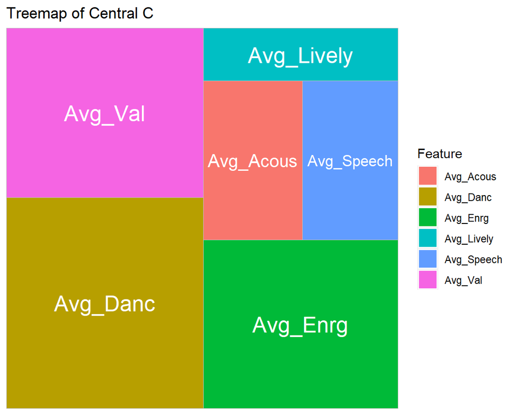

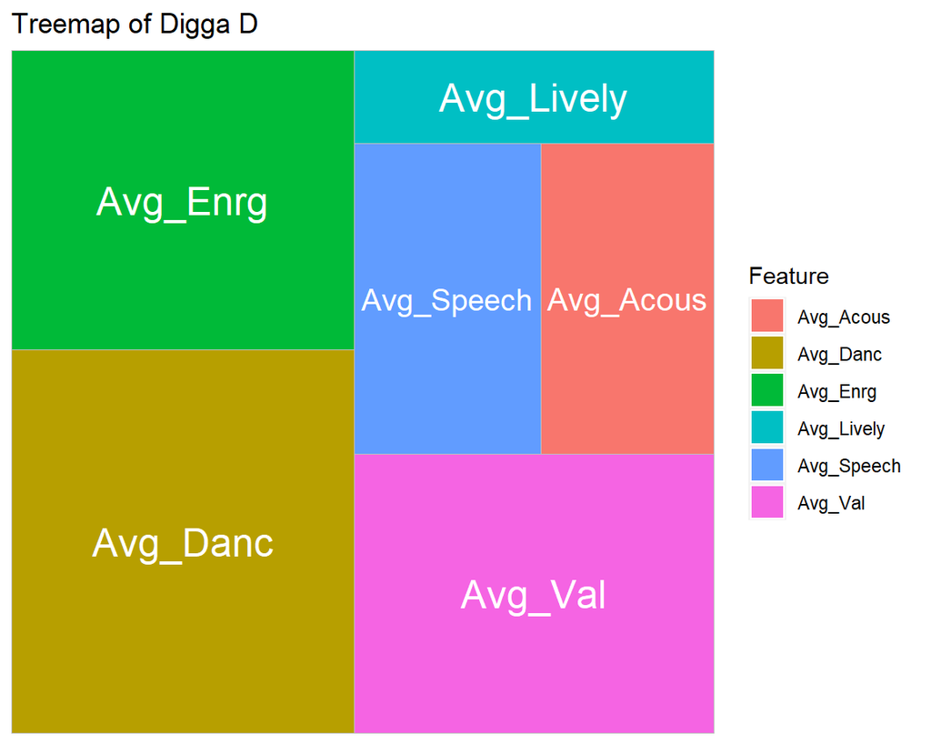

### Valence and energy of 3 different artists compared to each other

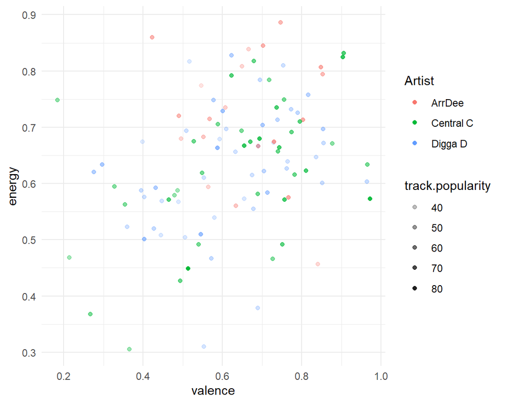

### The average valence and energy of the previous plot

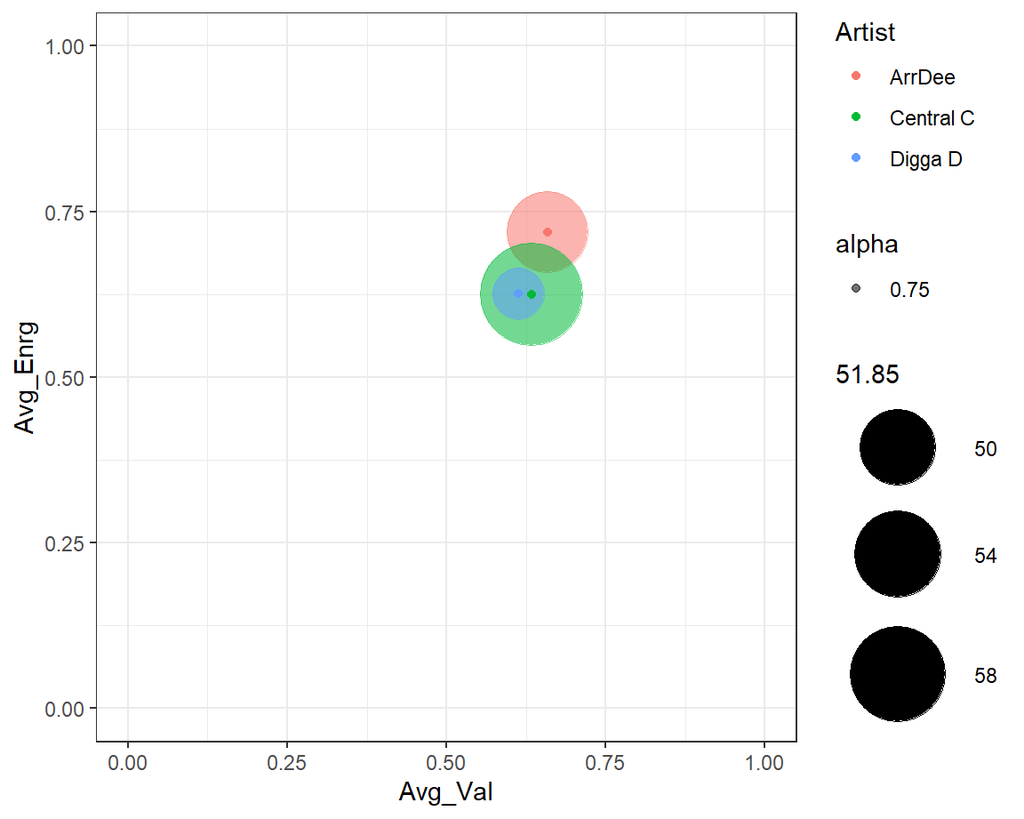